# FML Assignment 5

Roopali Aggarwal

2024-04-04

Instructions -

The purpose of this assignment is to use Hierarchical Clustering The dataset Cereals.csv includes nutritional information, store display, and consumer ratings for 77 breakfast cereals. Data Preprocessing. Remove all cereals with missing values.

```r
library(dplyr)
library(tidyverse)
library(caret)
library(factoextra)
library(flexclust)
```

```r
library(cluster)
library(ISLR)
library(ggplot2)
library(lattice)
library(knitr)
#Read the data using the working directory
Cereals.data <- read.csv("/Applications/Cereals.csv")
#Summary of the data, showing dimensions and structure
summary(Cereals.data)
```

```
##      name               mfr                type              calories
##  Length:77          Length:77          Length:77          Min.   : 50.0
##  Class :character   Class :character   Class :character   1st Qu.:100.0
##  Mode  :character   Mode  :character   Mode  :character   Median :110.0
##                                                           Mean   :106.9
##                                                           3rd Qu.:110.0
##                                                           Max.   :160.0
##
##     protein           fat            sodium          fiber
##  Min.   :1.000   Min.   :0.000   Min.   :  0.0   Min.   : 0.000
##  1st Qu.:2.000   1st Qu.:0.000   1st Qu.:130.0   1st Qu.: 1.000
##  Median :3.000   Median :1.000   Median :180.0   Median : 2.000
##  Mean   :2.545   Mean   :1.013   Mean   :159.7   Mean   : 2.152
##  3rd Qu.:3.000   3rd Qu.:2.000   3rd Qu.:210.0   3rd Qu.: 3.000
##  Max.   :6.000   Max.   :5.000   Max.   :320.0   Max.   :14.000
##
##      carbo          sugars           potass          vitamins
##  Min.   : 5.0   Min.   : 0.000   Min.   : 15.00   Min.   :  0.00
##  1st Qu.:12.0   1st Qu.: 3.000   1st Qu.: 42.50   1st Qu.: 25.00
##  Median :14.5   Median : 7.000   Median : 90.00   Median : 25.00
##  Mean   :14.8   Mean   : 7.026   Mean   : 98.67   Mean   : 28.25
##  3rd Qu.:17.0   3rd Qu.:11.000   3rd Qu.:120.00   3rd Qu.: 25.00
##  Max.   :23.0   Max.   :15.000   Max.   :330.00   Max.   :100.00
##  NA's   :1      NA's   :1        NA's   :2
##      shelf           weight          cups           rating
##  Min.   :1.000   Min.   :0.50   Min.   :0.250   Min.   :18.04
##  1st Qu.:1.000   1st Qu.:1.00   1st Qu.:0.670   1st Qu.:33.17
##  Median :2.000   Median :1.00   Median :0.750   Median :40.40
##  Mean   :2.208   Mean   :1.03   Mean   :0.821   Mean   :42.67
##  3rd Qu.:3.000   3rd Qu.:1.00   3rd Qu.:1.000   3rd Qu.:50.83
##  Max.   :3.000   Max.   :1.50   Max.   :1.500   Max.   :93.70
##
```

```r
str(Cereals.data)
```

```
## 'data.frame':    77 obs. of  16 variables:
##  $ name    : chr  "100%_Bran" "100%_Natural_Bran" "All-Bran" "All-Bran_with_Extra_Fiber" ...
##  $ mfr     : chr  "N" "Q" "K" "K" ...
##  $ type    : chr  "C" "C" "C" "C" ...
##  $ calories: int  70 120 70 50 110 110 110 130 90 90 ...
##  $ protein : int  4 3 4 4 2 2 2 3 2 3 ...
##  $ fat     : int  1 5 1 0 2 2 0 2 1 0 ...
##  $ sodium  : int  130 15 260 140 200 180 125 210 200 210 ...
##  $ fiber   : num  10 2 9 14 1 1.5 1 2 4 5 ...
##  $ carbo   : num  5 8 7 8 14 10.5 11 18 15 13 ...
##  $ sugars  : int  6 8 5 0 8 10 14 8 6 5 ...
##  $ potass  : int  280 135 320 330 NA 70 30 100 125 190 ...
##  $ vitamins: int  25 0 25 25 25 25 25 25 25 25 ...
##  $ shelf   : int  3 3 3 3 3 1 2 3 1 3 ...
##  $ weight  : num  1 1 1 1 1 1 1 1.33 1 1 ...
##  $ cups    : num  0.33 1 0.33 0.5 0.75 0.75 1 0.75 0.67 0.67 ...
##  $ rating  : num  68.4 34 59.4 93.7 34.4 ...
```

```r
head(Cereals.data)
```

```
##                        name mfr type calories protein fat sodium fiber carbo
## 1                 100%_Bran   N    C       70       4   1    130  10.0   5.0
## 2         100%_Natural_Bran   Q    C      120       3   5     15   2.0   8.0
## 3                  All-Bran   K    C       70       4   1    260   9.0   7.0
## 4 All-Bran_with_Extra_Fiber   K    C       50       4   0    140  14.0   8.0
## 5            Almond_Delight   R    C      110       2   2    200   1.0  14.0
## 6   Apple_Cinnamon_Cheerios   G    C      110       2   2    180   1.5  10.5
##   sugars potass vitamins shelf weight cups   rating
## 1      6    280       25     3      1 0.33 68.40297
## 2      8    135        0     3      1 1.00 33.98368
## 3      5    320       25     3      1 0.33 59.42551
## 4      0    330       25     3      1 0.50 93.70491
## 5      8     NA       25     3      1 0.75 34.38484
## 6     10     70       25     1      1 0.75 29.50954
```

```r
#Removing rows with missing values
data <- na.omit(Cereals.data)
#Extracting only the numerical variables
num.data <- data[, c(4:16)]
num.data
```

```
##    calories protein fat sodium fiber carbo sugars potass vitamins shelf weight
## 1        70       4   1    130  10.0   5.0      6    280       25     3   1.00
## 2       120       3   5     15   2.0   8.0      8    135        0     3   1.00
## 3        70       4   1    260   9.0   7.0      5    320       25     3   1.00
## 4        50       4   0    140  14.0   8.0      0    330       25     3   1.00
## 6       110       2   2    180   1.5  10.5     10     70       25     1   1.00
## 7       110       2   0    125   1.0  11.0     14     30       25     2   1.00
## 8       130       3   2    210   2.0  18.0      8    100       25     3   1.33
## 9        90       2   1    200   4.0  15.0      6    125       25     1   1.00
## 10       90       3   0    210   5.0  13.0      5    190       25     3   1.00
## 11      120       1   2    220   0.0  12.0     12     35       25     2   1.00
## 12      110       6   2    290   2.0  17.0      1    105       25     1   1.00
## 13      120       1   3    210   0.0  13.0      9     45       25     2   1.00
## 14      110       3   2    140   2.0  13.0      7    105       25     3   1.00
## 15      110       1   1    180   0.0  12.0     13     55       25     2   1.00
```

[output cut: 135 more lines]

```r
#Standardizing the dataset
data.norm <- preProcess(num.data , method = c("center", "scale"))
df <- predict(data.norm , num.data)
df
```

```
##      calories    protein        fat      sodium       fiber       carbo
## 1  -1.8659155  1.3817478  0.0000000 -0.39102269  3.22866747 -2.50013957
## 2   0.6537514  0.4522084  3.9728810 -1.78041856 -0.07249167 -1.72926320
## 3  -1.8659155  1.3817478  0.0000000  1.17959872  2.81602258 -1.98622199
## 4  -2.8737823  1.3817478 -0.9932203 -0.27020566  4.87924705 -1.72926320
## 6   0.1498180 -0.4773310  0.9932203  0.21306247 -0.27881412 -1.08686623
## 7   0.1498180 -0.4773310 -0.9932203 -0.45143121 -0.48513656 -0.95838683
## 8   1.1576848  0.4522084  0.9932203  0.57551356 -0.07249167  0.84032469
## 9  -0.8580487 -0.4773310  0.0000000  0.45469653  0.75279812  0.06944832
## 10 -0.8580487  0.4522084 -0.9932203  0.57551356  1.16544301 -0.44446926
## 11  0.6537514 -1.4068705  0.9932203  0.69633060 -0.89778146 -0.70142805
## 12  0.1498180  3.2408266  0.9932203  1.54204982 -0.07249167  0.58336590
## 13  0.6537514 -1.4068705  1.9864405  0.57551356 -0.89778146 -0.44446926
## 14  0.1498180  0.4522084  0.9932203 -0.27020566 -0.07249167 -0.44446926
## 15  0.1498180 -1.4068705  0.0000000  0.21306247 -0.89778146 -0.70142805
```

[output cut: 210 more lines]

Following pre-processing and scaling, the total count of observations amounted to 74, as opposed to the initial 77. Specifically, only three records were identified with the value “NA”.

Question 1 - Apply hierarchical clustering to the data using Euclidean distance to the normalized measurements. Use Agnes to compare the clustering from single linkage, complete linkage, average linkage, and Ward. Choose the best method.

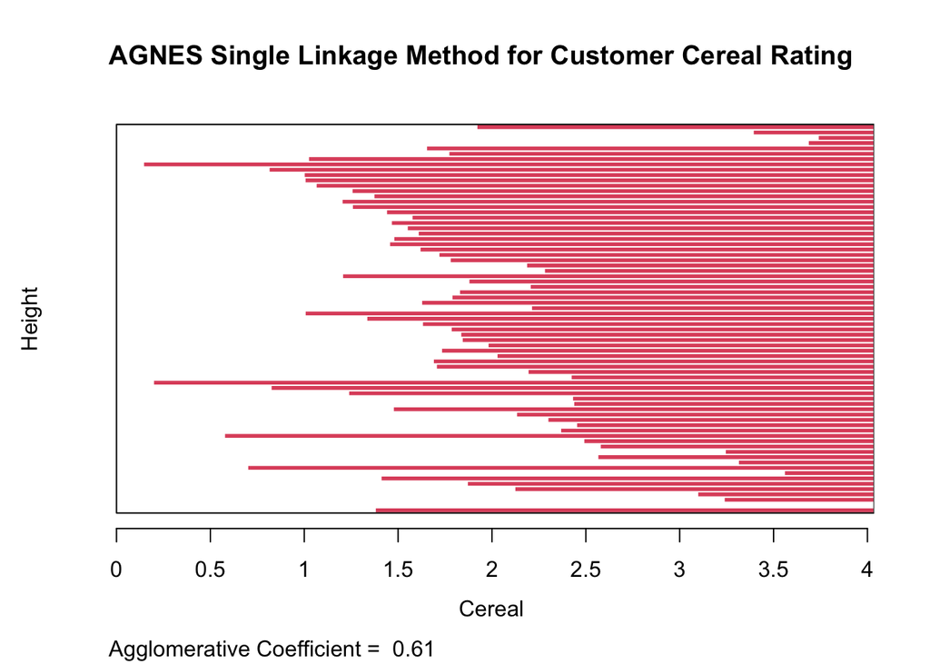

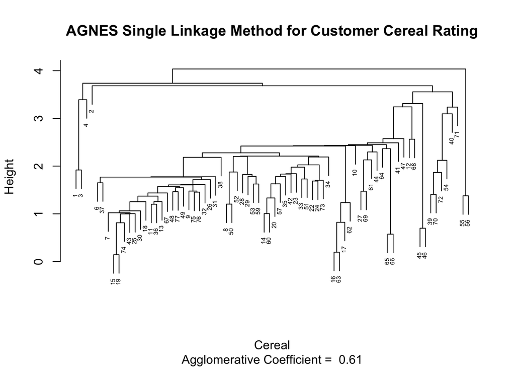

```r
#Dissimilarity matrix for all the numerical value using Euclidean method
distance <- dist(df, method = "euclidean")
#Perform hierarchical clustering using Agnes with different linkage methods and plotting the outcome
#Single Linkage Method
hc_single <- agnes(df,method = "single")
plot(hc_single, main = "AGNES Single Linkage Method for Customer Cereal Rating", xlab = "Cereal", ylab = "Height", cex.axis = 1, cex = 0.50)
```

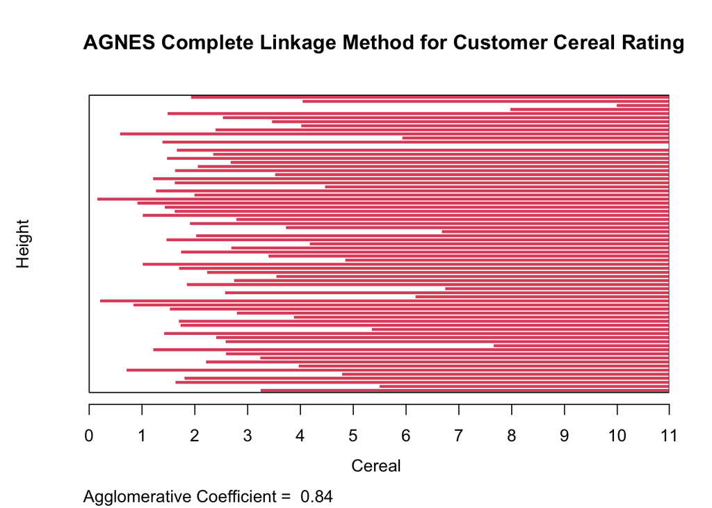

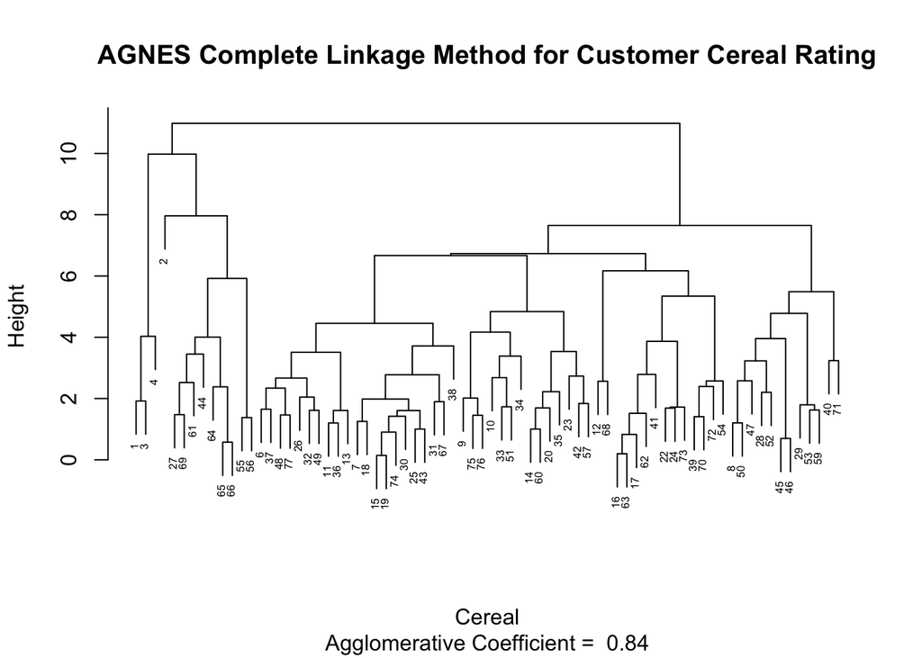

```r
#Complete Linkage Method
hc_complete <- agnes(df,method = "complete")
plot(hc_complete, main = "AGNES Complete Linkage Method for Customer Cereal Rating",   xlab = "Cereal", ylab = "Height", cex.axis = 1, cex = 0.50)
```

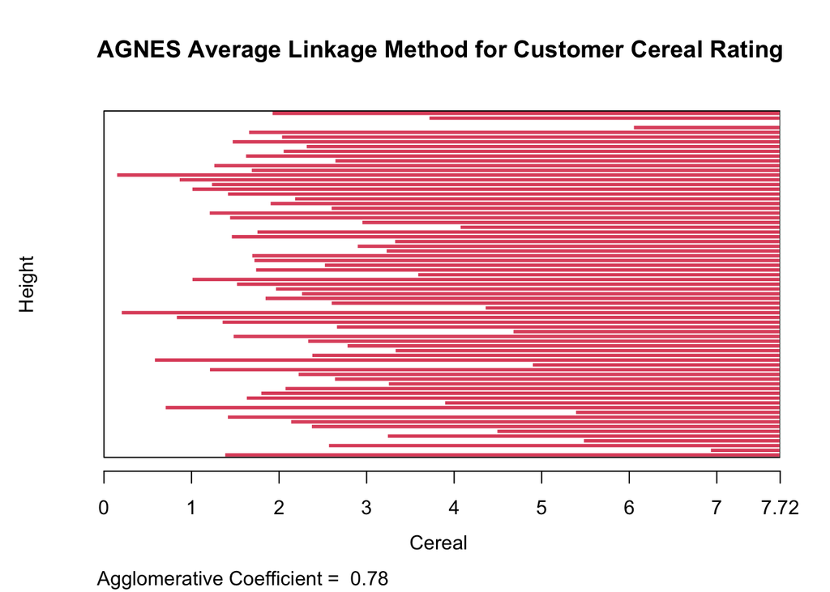

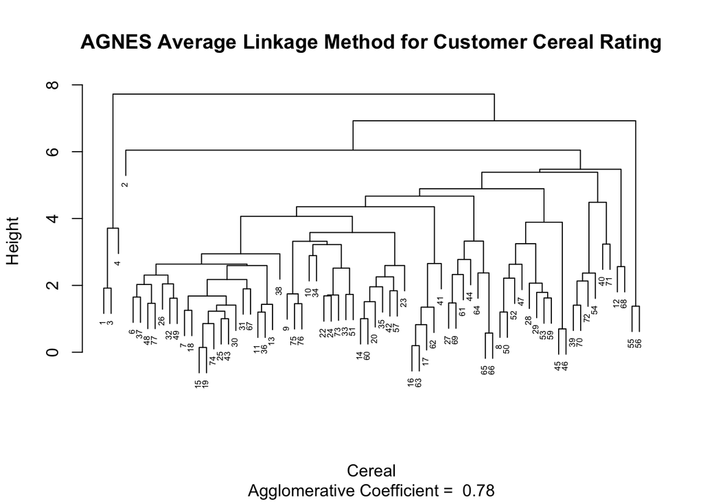

```r
#Average Linkage Method
hc_average <- agnes(df,method = "average")
plot(hc_average, main = "AGNES Average Linkage Method for Customer Cereal Rating", xlab = "Cereal", ylab = "Height", cex.axis = 1, cex = 0.50)
```

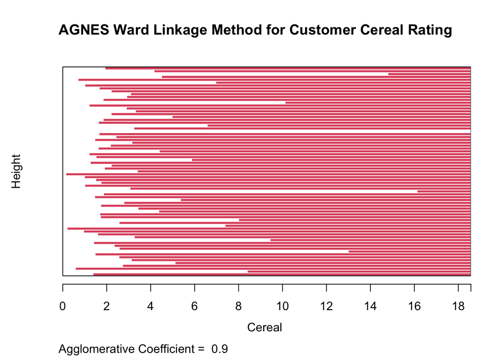

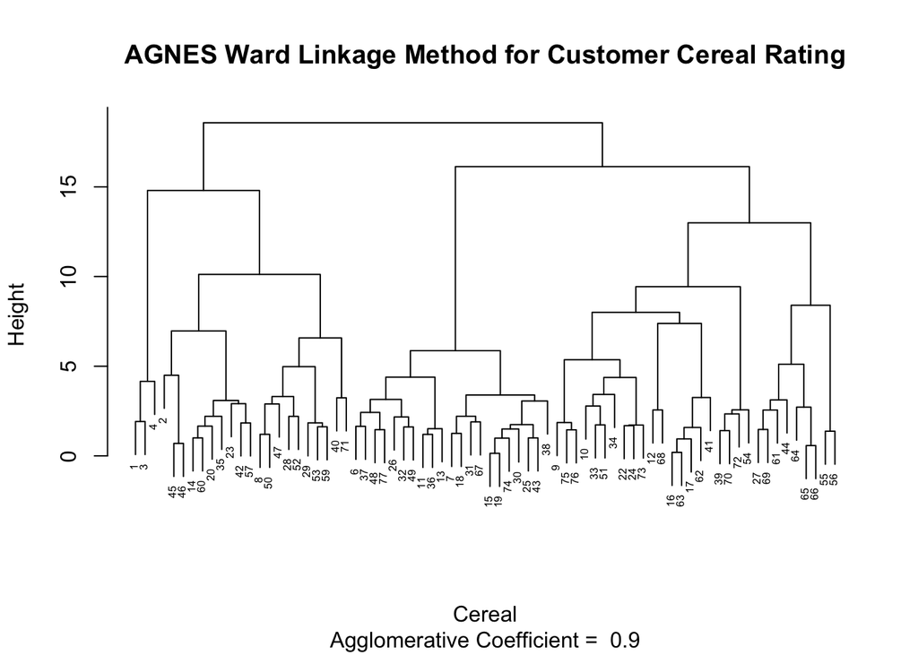

```r
#Ward Linkage Method
hc_ward <- agnes(df,method = "ward")
plot(hc_ward, main = "AGNES Ward Linkage Method for Customer Cereal Rating", xlab = "Cereal", ylab = "Height", cex.axis = 1, cex = 0.50)
```

The clustering method with values approaching 1.0 signifies a refined structure, guiding the selection process. Among the tested options, Single Linkage scored 0.61, Complete Linkage 0.84, and Average Linkage 0.78, while the Ward Linkage stood out with a score of 0.90. Consequently, the data indicates that the Ward technique is the most effective clustering strategy. It produced clusters where cereals within each group exhibited high similarity and clear distinction from cereals in other groups, aligning with the goal of grouping similar cereals together while ensuring distinctiveness among groups. Hence, Ward’s method emerges as the optimal choice, providing the clearest and most distinct cereal groupings.

Question 2 - How many clusters would you choose?

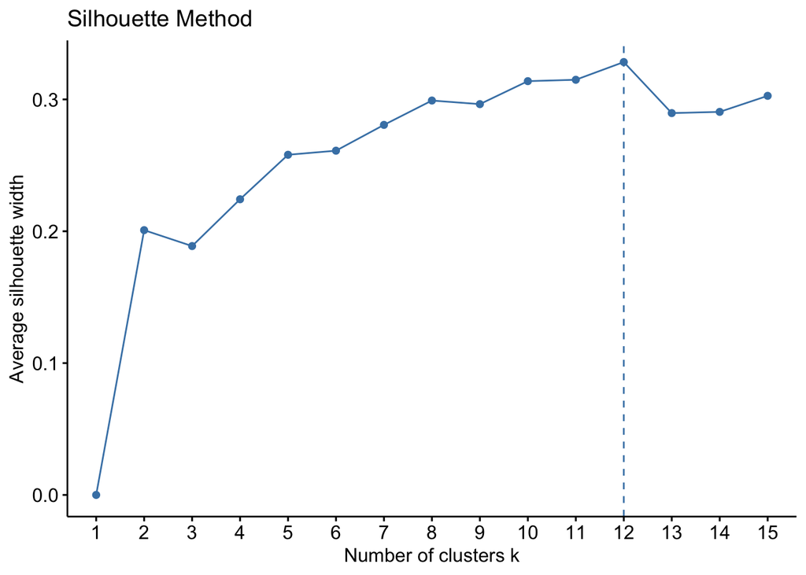

```r
#Finding the numbers of clusters using silhouette and elbow method
fviz_nbclust(df, hcut, method = "silhouette", k.max = 15) +
 labs(title = "Silhouette Method")
```

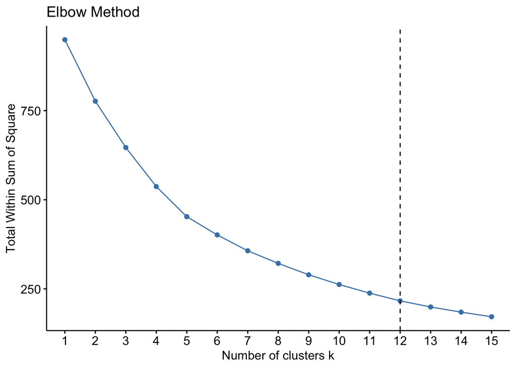

```r
fviz_nbclust(df, hcut, method = "wss", k.max = 15) + labs(title = "Elbow Method") +
  geom_vline(xintercept = 12, linetype=2)
```

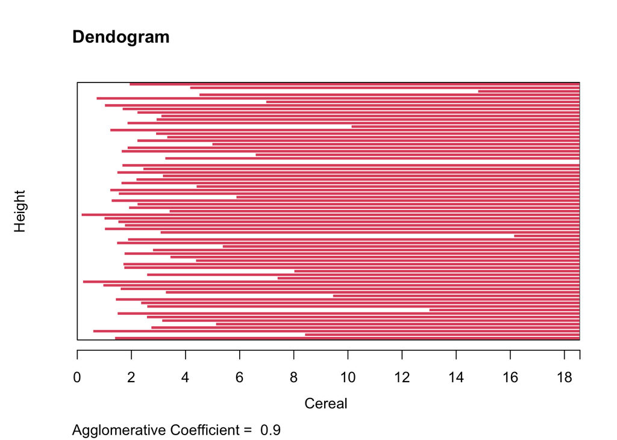

```r
#Plotting the Dendogram
plot(hc_ward, main = "Dendogram", xlab = "Cereal", ylab = "Height", cex.axis = 1, cex = 0.50)
```

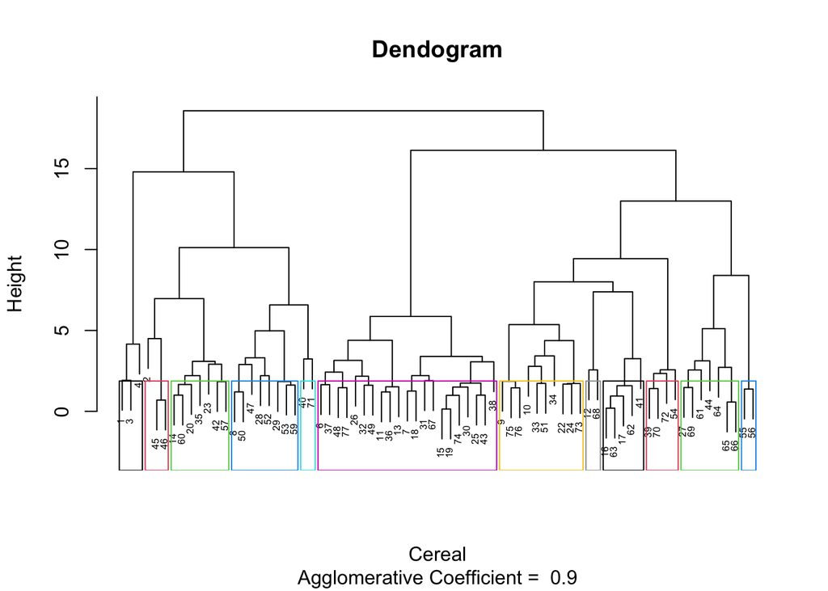

```r
rect.hclust(hc_ward, k = 12, border = 1:12)
```

Based on the Dendogram, there would be 12 clusters

Question 3 - Comment on the structure of the clusters and on their stability. Hint: To check stability,partition the data and see how well clusters formed based on one part apply to the other part. To do this: ● Cluster partition A ● Use the cluster centroids from A to assign each record in partition B (each record is assigned to the cluster with the closest centroid). ● Assess how consistent the cluster assignments are compared to the assignments based on all the data.

```r
clust1 <- cutree(hc_ward, k=12)
y3 <- as.data.frame(cbind(df,clust1))
```

```r
#Partitioning into group A & group B
set.seed(123)
newdata <- Cereals.data
new.df <- na.omit(newdata)
train_data <- new.df[1:55,]
test_data <- new.df[56:74,]
#Conducting hierarchical clustering with a consideration for K = 12
hc_ward1 <- agnes(scale(train_data[,-c(1:3)]),method = "ward")
hc_average1 <- agnes(scale(train_data[,-c(1:3)]),method="average")
hc_complete1 <- agnes(scale(train_data[,-c(1:3)]),method="complete")
hc_single1 <- agnes(scale(train_data[,-c(1:3)]),method="single")
kable(cbind(ward=hc_ward1$ac,average=hc_average1$ac,complete=hc_complete$ac,single=hc_single1$ac))
```

| ward | average | complete | single |
| --- | --- | --- | --- |
| 0.8808195 | 0.7449303 | 0.8353712 | 0.6564842 |

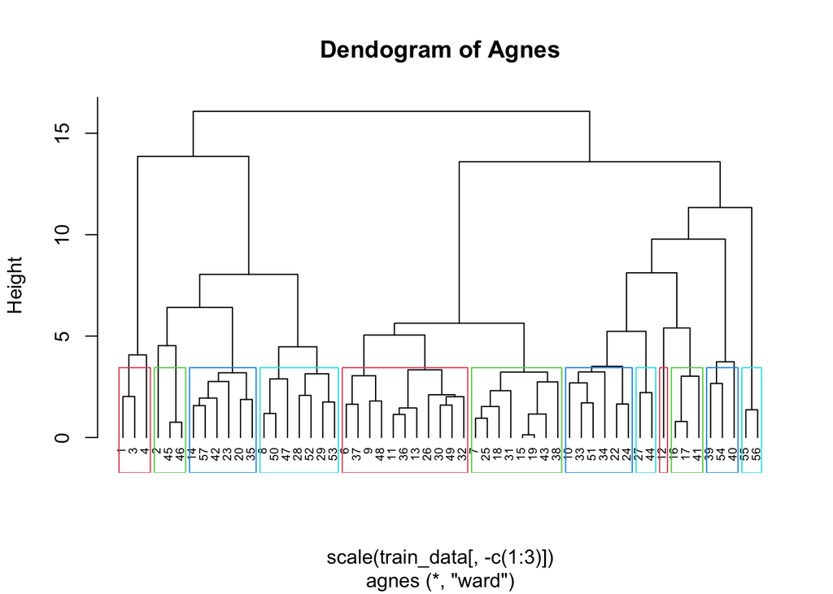

```r
pltree(hc_ward1, cex = 0.6, hang = -1, main = "Dendogram of Agnes")
rect.hclust(hc_ward1, k = 12, border = 2:5)
```

```r
clust2 <- cutree(hc_ward1, k=12)
result <- as.data.frame(cbind(scale(train_data[,-c(1:3)]),clust2))
result[result$clust2==1,]
```

```
##    calories  protein       fat     sodium    fiber     carbo     sugars
## 1 -1.756273 1.372219 -0.116808 -0.4910631 2.922741 -2.412296 -0.4124156
## 3 -1.756273 1.372219 -0.116808  1.2133549 2.546716 -1.881060 -0.6563173
## 4 -2.680627 1.372219 -1.034585 -0.3599540 4.426841 -1.615442 -1.8758258
##     potass   vitamins     shelf     weight      cups   rating clust2
## 1 2.434038 -0.1479841 0.8445408 -0.1860883 -1.928549 2.006069      1
## 3 2.972217 -0.1479841 0.8445408 -0.1860883 -1.928549 1.354952      1
## 4 3.106762 -0.1479841 0.8445408 -0.1860883 -1.248355 3.841165      1
```

```r
#First Centroid
center1 <- colMeans(result[result$clust2==1,])
result[result$clust2==2,]
```

```
##     calories   protein      fat     sodium       fiber     carbo    sugars
## 2  0.5546124 0.4518282 3.554299 -1.9988174 -0.08546026 -1.615442 0.0753878
## 45 1.9411435 1.3722190 1.718746 -0.9499448  0.29056488  0.509504 0.8070929
## 46 1.9411435 1.3722190 1.718746 -0.2288449  0.29056488  0.509504 0.8070929
##       potass   vitamins     shelf     weight     cups     rating clust2
## 2  0.4831382 -1.5045049 0.8445408 -0.1860883 0.752214 -0.4902899      2
## 45 0.9540450 -0.1479841 0.8445408 -0.1860883 0.752214 -0.2615961      2
## 46 0.9540450 -0.1479841 0.8445408 -0.1860883 0.752214 -0.4789693      2
```

```r
#Second Centroid
center2<-colMeans(result[result$clust2==2,])
result[result$clust2==3,]
```

```
##      calories    protein        fat     sodium       fiber      carbo
## 6   0.0924354 -0.4685626  0.8009688  0.1644823 -0.27347283 -0.9513961
## 9  -0.8319186 -0.4685626 -0.1168080  0.4267004  0.66659002  0.2438858
## 11  0.5546124 -1.3889534  0.8009688  0.6889186 -0.83751054 -0.5529688
## 13  0.5546124 -1.3889534  1.7187456  0.5578095 -0.83751054 -0.2873506
## 26  0.0924354 -1.3889534 -1.0345847  0.4267004 -0.46148540 -0.0217324
## 30  0.0924354 -1.3889534 -0.1168080 -0.4255085 -0.83751054 -0.2873506
## 32  0.0924354 -1.3889534 -0.1168080  1.4755730 -0.83751054  0.2438858
## 36  0.5546124 -1.3889534  0.8009688  0.6889186 -0.46148540 -0.5529688
## 37  0.0924354  0.4518282 -0.1168080  1.0822458 -0.27347283 -0.6857779
## 48 -0.3697416 -0.4685626 -0.1168080  0.6889186 -0.08546026  0.2438858
## 49  0.5546124 -0.4685626 -0.1168080  0.2955914 -0.83751054  0.2438858
##        sugars     potass   vitamins      shelf     weight       cups
## 6   0.5631912 -0.3914031 -0.1479841 -1.7360004 -0.1860883 -0.2480706
## 9  -0.4124156  0.3485934 -0.1479841 -1.7360004 -0.1860883 -0.5681616
```

[output cut: 21 more lines]

```r
#Third Centroid
center3<-colMeans(result[result$clust2==3,])
result[result$clust2==4,]
```

```
##      calories    protein       fat     sodium      fiber      carbo    sugars
## 7   0.0924354 -0.4685626 -1.034585 -0.5566176 -0.4614854 -0.8185870 1.5387980
## 15  0.0924354 -1.3889534 -0.116808  0.1644823 -0.8375105 -0.5529688 1.2948963
## 18  0.0924354 -1.3889534 -1.034585 -1.0154994 -0.4614854 -0.2873506 1.0509946
## 19  0.0924354 -1.3889534 -0.116808  0.1644823 -0.8375105 -0.5529688 1.2948963
## 25  0.0924354 -0.4685626 -0.116808 -0.5566176 -0.4614854 -0.8185870 1.2948963
## 31 -0.3697416 -0.4685626 -1.034585 -1.6054902 -0.8375105 -0.8185870 1.7826997
## 38  0.0924354 -1.3889534 -1.034585  0.1644823 -0.8375105 -0.0217324 0.8070929
## 43  0.0924354 -0.4685626 -0.116808  0.1644823 -0.8375105 -0.5529688 1.0509946
##        potass   vitamins      shelf     weight      cups     rating clust2
## 7  -0.9295823 -0.1479841 -0.4457298 -0.1860883 0.7522140 -0.5490074      4
## 15 -0.5932203 -0.1479841 -0.4457298 -0.1860883 0.7522140 -1.3060280      4
## 18 -1.0641271 -0.1479841 -0.4457298 -0.1860883 0.7522140 -0.3598041      4
## 19 -0.4586755 -0.1479841 -0.4457298 -0.1860883 0.7522140 -1.3306826      4
## 25 -0.9295823 -0.1479841 -0.4457298 -0.1860883 0.7522140 -0.6191065      4
## 31 -0.7950375 -0.1479841 -1.7360004 -0.1860883 0.2720774 -0.3982690      4
## 38 -0.8623099 -0.1479841 -1.7360004 -0.1860883 2.0725896 -0.8704278      4
## 43 -0.5932203 -0.1479841 -0.4457298 -0.1860883 0.7522140 -1.0160565      4
```

```r
#Fourth Centroid
center4<-colMeans(result[result$clust2==4,])
centers<-rbind(center1,center2,center3,center4)
#Calculating the distance
x2 <- as.data.frame(rbind(centers[,-14],scale(test_data[,-c(1:3)])))
y1 <- get_dist(x2)
y2 <- as.matrix(y1)
d1 <- data.frame(data=seq(1,nrow(test_data),1),clusters=rep(0,nrow(test_data)))
for(i in 1:nrow(test_data))
{
  d1[i,2]<-which.min(y2[i+4,1:4])
}
d1
```

```
##    data clusters
## 1     1        2
## 2     2        2
## 3     3        3
## 4     4        3
## 5     5        3
## 6     6        4
## 7     7        1
## 8     8        3
## 9     9        4
## 10   10        3
## 11   11        4
## 12   12        3
## 13   13        2
## 14   14        3
## 15   15        3
## 16   16        4
## 17   17        3
## 18   18        3
## 19   19        3
```

```r
cbind(y3$clust1[56:74],d1$clusters)
```

```
##       [,1] [,2]
##  [1,]    4    2
##  [2,]    7    2
##  [3,]    9    3
##  [4,]    8    3
##  [5,]    8    3
##  [6,]    9    4
##  [7,]    9    1
##  [8,]    9    3
##  [9,]    3    4
## [10,]    6    3
## [11,]    9    4
## [12,]   10    3
## [13,]   11    2
## [14,]   10    3
## [15,]    5    3
## [16,]    3    4
## [17,]    5    3
## [18,]    5    3
## [19,]    3    3
```

```r
table(y3$clust1[56:74]==d1$clusters)
```

```
##
## FALSE  TRUE
##    18     1
```

Model stability: Demonstrates high instability owing to the scarcity of “TRUE” values.

Question 4 - The elementary public schools would like to choose a set of cereals to include in their daily cafeterias. Every day a different cereal is offered, but all cereals should support a healthy diet. For this goal, you are requested to find a cluster of “healthy cereals.” Should the data be normalized? If not, how should they be used in the cluster analysis?

```r
#Grouping "Nutritious Cereals"
healthy.df <- df[, c("calories", "protein", "fat", "fiber", "carbo", "sugars", "potass", "vitamins")]
#Dissimilarity matrix using euclidean method
distance <- dist(healthy.df, method = "euclidean")
hc <- hclust(distance, method = "ward.D2")
#Creating 12 clusters as value of k is 12
df$cluster <- cutree(hc, k = 12)
summary.df <- aggregate(. ~ cluster, data = df, FUN = mean)
summary.df
```

```
##    cluster    calories     protein        fat      sodium      fiber
## 1        1 -2.20187108  1.38174776 -0.3310734  0.17279012  3.6413124
## 2        2  0.48577362  0.45220836  2.6485874 -1.03538019  0.3401532
## 3        3  0.14981803  0.14236189  0.6621468  0.09224544 -0.1412658
## 4        4  0.23380693 -1.04538290 -0.0551789  0.03183692 -0.7373084
## 5        5  1.96397821  0.82402412  1.3905084  0.03183692  0.2576242
## 6        6 -0.62287982  0.08039260 -0.6621468 -0.55613930  0.3401532
## 7        7 -0.15254200  2.12537929  0.1986441 -0.01648989 -0.3200786
## 8        8  0.07782755 -0.61012239 -0.7094430  1.19685830 -0.7798829
## 9        9  0.65375141  0.45220836  0.0000000  0.48490079  1.2686042
## 10      10 -0.10214866 -0.01256134 -0.2483051  0.72653485 -0.3819753
## 11      11  1.66161818  0.45220836  0.0000000  0.21306247  0.3401532
## 12      12 -2.87378226 -0.94210075 -0.9932203 -1.96164410 -0.6914590
##          carbo     sugars      potass   vitamins      shelf      weight
## 1  -2.07187492 -0.7894824  2.98378133 -0.1818422  0.9419715 -0.20083243
```

[output cut: 24 more lines]

Based on the provided cluster information, we can identify the best cluster for children as the one with the most favorable nutritional attributes. From the given data, Cluster 1 appears to be the healthiest option for children. Here’s the explanation:

Low Fat and Sugar: Cluster 1 also has relatively low fat and sugar content, which is crucial for preventing obesity, diabetes, and other related health issues.

High Fiber: Fiber is important for digestive health and helps regulate blood sugar levels. Cluster 1 exhibits the highest fiber content, promoting satiety and aiding in digestion.

Balanced Nutrients: Overall, Cluster 1 demonstrates a balanced nutritional profile with adequate levels of vitamins and minerals, such as potassium and vitamins, essential for overall health and well-being.

Here, we have already done the normalizing on the data above, so there’s no need to normalize it again. This ensures that the comparison between clusters is based on standardized values, providing a fair assessment of their nutritional quality.